# Sensitivity analyses Cu BLM

Cecilia Albert-Black

# Objectives

To conduct sensitivity analyses of two BLM assumptions

- **Carbonate charge balance**
  - Baseline: Closed system, measured DIC as input
  - Perturbed: Open system, no DIC input, alkalinity estimated by charge balance (assuming in equilibrium with atmospheric partial pressure)
- **Humic acid fraction of DOC**
  - Baseline: HA = 10% (suggested by the BLM manual)
  - Perturbed: HA = 80%

We’ll be conducting the sensitivity analysis on the BLM output in speciation mode only.

# 1. Setup

We will merge BLM output variables from the baseline conditions (closed system + HA 10%) and the perturbed scenarios (open system + HA 10% and closed system + HA 80%) from the clean Bioavailability Master Spreadsheet version 2 (pre-typology) and version 3 (with typological classification).

First, we’ll set the working directory and import each dataset as it’s own object

```r
library(readxl)

# -------------------------------------------------
# 1) Set working directory
# -------------------------------------------------
setwd("C:/Users/q4q/OneDrive - Oak Ridge National Laboratory/Research/Bioavailability Project/BLM_spatial_assessmt/Copper/6. Sensitivity analyses")

# -------------------------------------------------
# 2) Store file paths once (so you don't repeat them)
# -------------------------------------------------
file_master3 <- "C:/Users/q4q/OneDrive - Oak Ridge National Laboratory/Research/Bioavailability Project/BLM_spatial_assessmt/Copper/5. Statistical data analysis/Bioavailability_Master_Spreadsheet_Clean3.xlsx"

file_master2 <- "C:/Users/q4q/OneDrive - Oak Ridge National Laboratory/Research/Bioavailability Project/BLM_spatial_assessmt/Copper/4. Exploratory data analysis/Bioavailability_Master_Spreadsheet_Clean2.xlsx"
```

Now we’ll read each file and create the following scenarios as their own objects

- ha_10_cs
- ha_10_os
- ha_80_cs

```r
library(dplyr)
read_scenario <- function(path, sheet) {
  read_excel(path, sheet = sheet)
}

ha_10_cs <- read_scenario(file_master3, "HA 10% Closed System")
ha_10_os <- read_scenario(file_master2, "HA 10% Open System")
ha_80_cs <- read_scenario(file_master2, "HA 80% Closed System")
```

Now we’ll add typology from ha_10_cs to each scenario

```r
library(dplyr)

typology_lookup <- ha_10_cs %>%
  dplyr::select(Sample_ID, Typology) %>%
  distinct()

ha_10_os <- ha_10_os %>%
  left_join(typology_lookup, by = "Sample_ID") %>%
  dplyr::select(Sample_ID, Typology, everything())

ha_80_cs <- ha_80_cs %>%
  left_join(typology_lookup, by = "Sample_ID") %>%
  dplyr::select(Sample_ID, Typology, everything())

ha_10_cs <- ha_10_cs %>%
  dplyr::select(Sample_ID, Typology, everything())

# quick sanity check: check if there are Sample_IDs that don't match (should be 0)
setdiff(ha_10_os$Sample_ID, ha_10_cs$Sample_ID)
```

```
## character(0)
```

```r
setdiff(ha_80_cs$Sample_ID, ha_10_cs$Sample_ID)
```

```
## character(0)
```

# 2. Carbonate assumption SA

## a. Select variables of interest

First, we’ll create a paired dataset

```r
library(dplyr)

# Only retain BLM speciation mode output variables in nM and nmol/g for simplicity and consistency (one column per variable and all in same units of measurement)
ha_10_cs <- ha_10_cs %>%
  dplyr::select(
    Sample_ID,
    ends_with("_nM"),
    ends_with("_nmol_kg"),
    # log-transformed variables
    -starts_with("log_"),
    # BLM predictors
    -"DOC_nM",
    -"Ca_nM",
    -"Mg_nM",
    -"Na_nM",
    -"K_nM",
    -"SO4_nM",
    -"Cl_nM",
    -"pH",
    -"DIC_nM",
    -"Zn_nM",
    -"Cu_nM",
    # Remove toxicity variables
    -starts_with("Cu_Chronic"),
    -starts_with("Cu_Acute")
  )

ha_10_os <- ha_10_os %>%
  dplyr::select(
    Sample_ID,
    ends_with("_nM"),
    ends_with("_nmol_kg"),
    # log-transformed variables
    -starts_with("log_"),
    # BLM predictors
    -"DOC_nM",
    -"Ca_nM",
    -"Mg_nM",
    -"Na_nM",
    -"K_nM",
    -"SO4_nM",
    -"Cl_nM",
    -"pH",
    -"DIC_nM",
    -"Zn_nM",
    -"Cu_nM",
    # Remove toxicity variables
    -starts_with("Cu_Chronic"),
    -starts_with("Cu_Acute")
   )
```

## b. Calculate sensitivity metrics

### i. Delta

Delta is the absolute change in a response variable from baseline to the perturbed BLM system assumptions; calculated as y_s2 - y_s1.

```r
library(dplyr)
library(stringr)

# 1. Separate the numeric data
num1 <- ha_10_cs %>%
  dplyr::select(where(is.numeric))

num2 <- ha_10_os %>%
  dplyr::select(where(is.numeric))

# 2. Subtract num1-num2
delta_dic <- ha_10_os %>%
  dplyr::select(Sample_ID) %>%
  bind_cols(num2 - num1)

# 3. Check
delta_dic
```

```
## # A tibble: 386 × 31
##    Sample_ID   Free_Cu_nM      CuOH_nM Cu_OH_2_nM  CuSO4_nM CuCO3_nM Cu_CO3_2_nM
##    <chr>            <dbl>        <dbl>      <dbl>     <dbl>    <dbl>       <dbl>
##  1 WaDE_62    0.00107          2.66e-4    4.35e-6  5.95e- 6 -6.56e-2    -3.07e-4
##  2 WaDE_63   -0.0000392       -2.37e-4   -6.08e-5 -1.94e- 6  1.43e-1     6.20e-3
##  3 WaDE_64    0.00000165       1.18e-5    2.60e-6  3.77e- 8 -6.57e-3    -4.86e-4
##  4 WaDE_65    0.0000268        4.13e-6   -6.69e-6 -4.81e- 8  5.16e-2     2.35e-3
##  5 WaDE_66   -0.000000238     -7.10e-8   -1.86e-9  8.89e-10 -4.48e-5    -1.41e-7
##  6 WaDE_67    0.00000730       2.15e-6    5.40e-8 -2.33e-10  4.00e-4     4.62e-7
##  7 WaDE_68   -0.0000154        2.20e-6    2.77e-7  9.72e- 8 -8.16e-3    -3.77e-5
##  8 WaDE_69    0.000347         2.72e-4    1.08e-5  3.64e- 6 -1.33e-1    -1.12e-3
##  9 WaDE_70    0.00000118       1.10e-5    1.97e-6  4.63e- 8 -8.16e-3    -2.56e-4
## 10 WaDE_71    0.000132         4.75e-4    9.26e-5  5.94e- 6 -2.29e-1    -1.28e-2
## # ℹ 376 more rows
## # ℹ 24 more variables: CuCl_nM <dbl>, CuHCO3_nM <dbl>, TOrg_Cu_nM <dbl>,
## #   HCO3_nM <dbl>, H2_CO3_nM <dbl>, HS_nM <dbl>, H2S_nM <dbl>, MgHCO3_nM <dbl>,
## #   MgCO3_nM <dbl>, MgSO4_nM <dbl>, CaHCO3_nM <dbl>, CaCO3_nM <dbl>,
## #   CaSO4_nM <dbl>, TOrg_H_nM <dbl>, TOrg_Ca_nM <dbl>, TOrg_Mg_nM <dbl>,
## #   TOrg_Na_nM <dbl>, TOrg_K_nM <dbl>, BL_Cu_nmol_kg <dbl>,
## #   BL_CuOH_nmol_kg <dbl>, BL_Ca_nmol_kg <dbl>, BL_H_nmol_kg <dbl>, …
```

Summarize delta by variable

```r
library(dplyr)
library(tidyr)

summary_delta_dic <- delta_dic %>%
  dplyr::select(where(is.numeric)) %>%
  summarise(across(everything(), list(
    min    = ~min(.x, na.rm = TRUE),
    q1     = ~quantile(.x, 0.25, na.rm = TRUE),
    median = ~median(.x, na.rm = TRUE),
    mean   = ~mean(.x, na.rm = TRUE),
    q3     = ~quantile(.x, 0.75, na.rm = TRUE),
    max    = ~max(.x, na.rm = TRUE),
    iqr    = ~IQR(.x, na.rm = TRUE)
  ))) %>%
  # Pivot so it's a readable list instead of 500 columns wide
  pivot_longer(everything(),
               names_to = c("Variable", ".value"),
               names_sep = "_(?!.*_)") # Splits at the last underscore

# Check
head(summary_delta_dic)
```

```
## # A tibble: 6 × 8
##   Variable           min           q1   median     mean       q3     max     iqr
##   <chr>            <dbl>        <dbl>    <dbl>    <dbl>    <dbl>   <dbl>   <dbl>
## 1 Free_Cu_nM  -0.00281   -0.00000783   3.63e-5  6.60e-4  4.53e-4 1.78e-2 4.61e-4
## 2 CuOH_nM     -0.0732     0.0000185    1.02e-4 -7.11e-5  3.67e-4 2.16e-2 3.49e-4
## 3 Cu_OH_2_nM  -0.212      0.000000549  4.61e-6 -9.99e-4  1.48e-5 1.71e-3 1.43e-5
## 4 CuSO4_nM    -0.0000839  0.000000779  4.58e-6  1.62e-5  9.85e-6 9.74e-4 9.07e-6
## 5 CuCO3_nM    -5.46      -0.185       -9.76e-2 -1.04e-1 -2.18e-2 1.33e+1 1.63e-1
## 6 Cu_CO3_2_nM -0.101     -0.00247     -6.58e-4  2.73e-1 -8.75e-5 5.10e+1 2.38e-3
```

### ii. Percent change

Percentage of delta

```r
# Multiply all numeric columns by 100
percent_change_dic <- delta_dic %>%
  dplyr::select(where(is.numeric)) * 100

# Check
head(percent_change_dic)
```

```
##      Free_Cu_nM       CuOH_nM    Cu_OH_2_nM      CuSO4_nM     CuCO3_nM
## 1  0.1068179399  2.655743e-02  4.347302e-04  5.947288e-04 -6.562176627
## 2 -0.0039208220 -2.366432e-02 -6.076780e-03 -1.940431e-04 14.312431795
## 3  0.0001654709  1.176712e-03  2.598751e-04  3.768947e-06 -0.657434870
## 4  0.0026823921  4.128425e-04 -6.687413e-04 -4.808479e-06  5.157972660
## 5 -0.0000238145 -7.101524e-06 -1.864743e-07  8.893846e-08 -0.004479555
## 6  0.0007295922  2.146016e-04  5.396362e-06 -2.333576e-08  0.040034859
##     Cu_CO3_2_nM       CuCl_nM     CuHCO3_nM   TOrg_Cu_nM    HCO3_nM   H2_CO3_nM
## 1 -3.071152e-02  4.287437e-05 -32.608665941  39.06528376 -356571472 -50806486.1
## 2  6.204213e-01 -3.140777e-06   6.022489799 -20.90708649  117525185   1393875.4
## 3 -4.862367e-02  9.094553e-08  -0.267989927   0.97209162  -91869989  -1115357.4
## 4  2.345304e-01 -4.393619e-08   1.932416466  -7.34569907  135888741   1503574.4
## 5 -1.414264e-05 -8.986490e-10  -0.007382072   0.01181872   -2158346   -111913.7
## 6  4.619961e-05  5.198400e-08   0.098720121  -0.13778821    6997801    553307.7
##           HS_nM        H2S_nM    MgHCO3_nM    MgCO3_nM     MgSO4_nM
```

[output cut: 27 more lines]

Check distributions of percent change

[figure not shown]

```r
library(dplyr)
library(tidyr)
library(ggplot2)

percent_change_dic %>%
  select(where(is.numeric)) %>%
  pivot_longer(
    cols = everything(),
    names_to = "variable",
    values_to = "value"
  ) %>%
  ggplot(aes(x = value)) +
  geom_histogram(bins = 40, na.rm = TRUE) +
  facet_wrap(~ variable, scales = "free", ncol = 5) +
  labs(
    title = "Distributions of numeric variables in lrr_dic",
    x = NULL,
    y = "Count"
  ) +
  theme_bw() +
  theme(
    strip.text = element_text(size = 8),
    axis.text.x = element_text(size = 7),
    axis.text.y = element_text(size = 7)
  )
```

Summarize percent change by variable

```r
library(dplyr)
library(tidyr)

summary_percent_change_dic <- percent_change_dic %>%
  dplyr::select(where(is.numeric)) %>%
  summarise(across(everything(), list(
    min    = ~min(.x, na.rm = TRUE),
    q1     = ~quantile(.x, 0.25, na.rm = TRUE),
    median = ~median(.x, na.rm = TRUE),
    mean   = ~mean(.x, na.rm = TRUE),
    q3     = ~quantile(.x, 0.75, na.rm = TRUE),
    max    = ~max(.x, na.rm = TRUE),
    iqr    = ~IQR(.x, na.rm = TRUE)
  ))) %>%
  # Pivot so it's a readable list instead of 500 columns wide
  pivot_longer(everything(),
               names_to = c("Variable", ".value"),
               names_sep = "_(?!.*_)") # Splits at the last underscore

# Check
head(summary_percent_change_dic)
```

```
## # A tibble: 6 × 8
##   Variable           min          q1    median     mean       q3     max     iqr
##   <chr>            <dbl>       <dbl>     <dbl>    <dbl>    <dbl>   <dbl>   <dbl>
## 1 Free_Cu_nM    -0.281    -0.000783   0.00363   6.60e-2  4.53e-2 1.78e+0 4.61e-2
## 2 CuOH_nM       -7.32      0.00185    0.0102   -7.11e-3  3.67e-2 2.16e+0 3.49e-2
## 3 Cu_OH_2_nM   -21.2       0.0000549  0.000461 -9.99e-2  1.48e-3 1.71e-1 1.43e-3
## 4 CuSO4_nM      -0.00839   0.0000779  0.000458  1.62e-3  9.85e-4 9.74e-2 9.07e-4
## 5 CuCO3_nM    -546.      -18.5       -9.76     -1.04e+1 -2.18e+0 1.33e+3 1.63e+1
## 6 Cu_CO3_2_nM  -10.1      -0.247     -0.0658    2.73e+1 -8.75e-3 5.10e+3 2.38e-1
```

### iii. Log response ratio (LRR)

```r
library(dplyr)

# 1. Log transform each dataframe
log_ha_10_cs <- ha_10_cs %>%
  mutate(across(where(is.numeric), log10))

log_ha_10_os <- ha_10_os %>%
  mutate(across(where(is.numeric), log10))

# 2. Separate the numeric log-transformed data
log_num1 <- log_ha_10_cs %>%
  dplyr::select(where(is.numeric))

log_num2 <- log_ha_10_os %>%
  dplyr::select(where(is.numeric))

# 3. Subtract num1-num2
lrr_dic <- ha_10_os %>%
  dplyr::select(Sample_ID) %>%
  bind_cols(log_num2 - log_num1)

# 4. Check
head(lrr_dic)
```

```
## # A tibble: 6 × 31
##   Sample_ID Free_Cu_nM   CuOH_nM Cu_OH_2_nM   CuSO4_nM CuCO3_nM Cu_CO3_2_nM
##   <chr>          <dbl>     <dbl>      <dbl>      <dbl>    <dbl>       <dbl>
## 1 WaDE_62     0.0563    0.0695     0.0747    0.0849     -1.23       -2.55
## 2 WaDE_63    -0.00417  -0.00891   -0.0108   -0.0143      0.347       0.711
## 3 WaDE_64     0.00299   0.00875    0.0109    0.0178     -0.138      -0.294
## 4 WaDE_65     0.0117    0.000535  -0.00358  -0.0192      0.402       0.824
## 5 WaDE_66    -0.000432 -0.000203  -0.000119  0.000195   -0.0178     -0.0357
## 6 WaDE_67     0.00340   0.00226    0.00186  -0.0000172   0.103       0.205
## # ℹ 24 more variables: CuCl_nM <dbl>, CuHCO3_nM <dbl>, TOrg_Cu_nM <dbl>,
## #   HCO3_nM <dbl>, H2_CO3_nM <dbl>, HS_nM <dbl>, H2S_nM <dbl>, MgHCO3_nM <dbl>,
## #   MgCO3_nM <dbl>, MgSO4_nM <dbl>, CaHCO3_nM <dbl>, CaCO3_nM <dbl>,
## #   CaSO4_nM <dbl>, TOrg_H_nM <dbl>, TOrg_Ca_nM <dbl>, TOrg_Mg_nM <dbl>,
## #   TOrg_Na_nM <dbl>, TOrg_K_nM <dbl>, BL_Cu_nmol_kg <dbl>,
## #   BL_CuOH_nmol_kg <dbl>, BL_Ca_nmol_kg <dbl>, BL_H_nmol_kg <dbl>,
## #   BL_Mg_nmol_kg <dbl>, BL_Na_nmol_kg <dbl>
```

Check distributions of LRRs

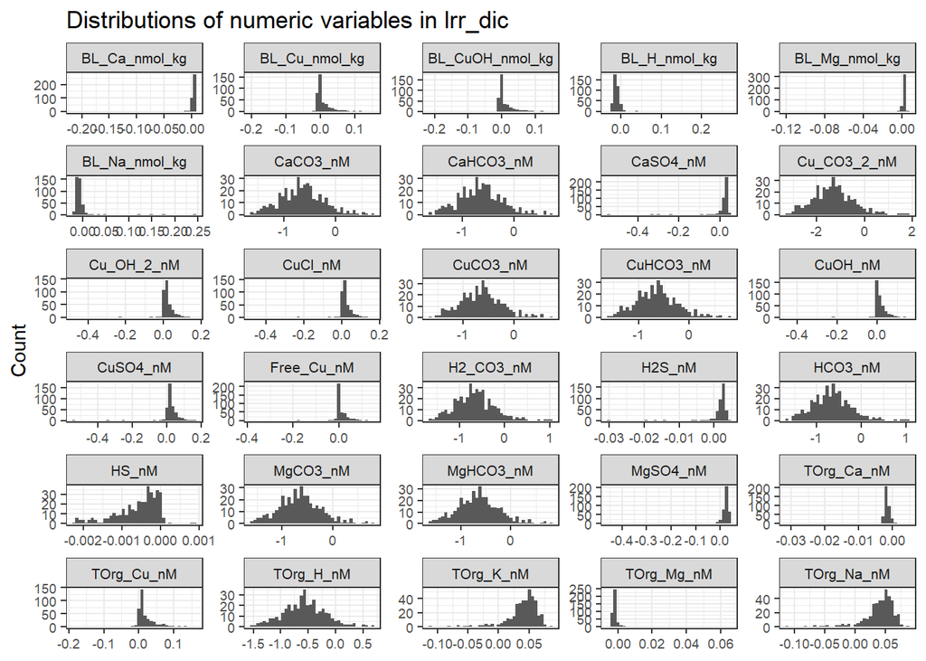

```r
library(dplyr)
library(tidyr)
library(ggplot2)

lrr_dic %>%
  select(where(is.numeric)) %>%
  pivot_longer(
    cols = everything(),
    names_to = "variable",
    values_to = "value"
  ) %>%
  ggplot(aes(x = value)) +
  geom_histogram(bins = 40, na.rm = TRUE) +
  facet_wrap(~ variable, scales = "free", ncol = 5) +
  labs(
    title = "Distributions of numeric variables in lrr_dic",
    x = NULL,
    y = "Count"
  ) +
  theme_bw() +
  theme(
    strip.text = element_text(size = 8),
    axis.text.x = element_text(size = 7),
    axis.text.y = element_text(size = 7)
  )
```

Summarize LRR for each numeric variable

```r
library(dplyr)
library(tidyr)

summary_lrr_dic <- lrr_dic %>%
  dplyr::select(where(is.numeric)) %>%
  summarise(across(everything(), list(
    min    = ~min(.x, na.rm = TRUE),
    q1     = ~quantile(.x, 0.25, na.rm = TRUE),
    median = ~median(.x, na.rm = TRUE),
    mean   = ~mean(.x, na.rm = TRUE),
    q3     = ~quantile(.x, 0.75, na.rm = TRUE),
    max    = ~max(.x, na.rm = TRUE),
    iqr    = ~IQR(.x, na.rm = TRUE)
  ))) %>%
  # Pivot so it's a readable list instead of 500 columns wide
  pivot_longer(everything(),
               names_to = c("Variable", ".value"),
               names_sep = "_(?!.*_)") # Splits at the last underscore

# Check
head(summary_lrr_dic)
```

```
## # A tibble: 6 × 8
##   Variable       min        q1   median    mean      q3   max    iqr
##   <chr>        <dbl>     <dbl>    <dbl>   <dbl>   <dbl> <dbl>  <dbl>
## 1 Free_Cu_nM  -0.376 -0.000753  0.00293  0.0109  0.0208 0.152 0.0216
## 2 CuOH_nM     -0.446  0.00401   0.00917  0.0171  0.0293 0.160 0.0252
## 3 Cu_OH_2_nM  -0.476  0.00615   0.0122   0.0196  0.0326 0.163 0.0265
## 4 CuSO4_nM    -0.531  0.0124    0.0185   0.0249  0.0395 0.170 0.0271
## 5 CuCO3_nM    -1.61  -0.916    -0.639   -0.638  -0.401  0.755 0.515
## 6 Cu_CO3_2_nM -3.26  -1.89     -1.32    -1.30   -0.819  1.80  1.07
```

### iv. Robustness

To assess directional consistency in LRR, we’ll summarize how many variables had a + or - LRR for each variable

```r
library(dplyr)

robustness_dic <- lrr_dic %>%
  dplyr::select(where(is.numeric)) %>%
  summarize(across(everything(), list(
    positive = ~sum(.x > 0, na.rm = TRUE),
    negative = ~sum(.x < 0, na.rm = TRUE),
    zero = ~sum(.x == 0, na.rm = TRUE)
  ))) %>%
  # Pivot for readability
  pivot_longer(everything(),
               names_to = c("Variable", ".value"),
               names_sep = "_(?!.*_)") %>%
  # Add the ratio of positive/negative LRR values
  mutate(ratio = positive/negative)

# Check
head(robustness_dic)
```

```
## # A tibble: 6 × 5
##   Variable    positive negative  zero   ratio
##   <chr>          <int>    <int> <int>   <dbl>
## 1 Free_Cu_nM       263      123     0  2.14
## 2 CuOH_nM          353       33     0 10.7
## 3 Cu_OH_2_nM       359       27     0 13.3
## 4 CuSO4_nM         364       22     0 16.5
## 5 CuCO3_nM          23      363     0  0.0634
## 6 Cu_CO3_2_nM       23      363     0  0.0634
```

## c. Export SA results

Now we’ll compile all of the output to one excel sheet

```r
library(openxlsx)

# Create a list of all output objects
dic_sa_list <- list(
  "Delta"              = summary_delta_dic,
  "Percent Change"     = summary_percent_change_dic,
  "Log Response Ratio"        = summary_lrr_dic,
  "Robustness"         = robustness_dic
)

# Write into excel file
write.xlsx(dic_sa_list, file = "Carbonate_system_SA.xlsx", overwrite = TRUE)
```

## d. Plots

### i. Percent change

```r
library(dplyr)

# 1. Pivot table: turn columns into rows
long_percent_change_dic <- percent_change_dic %>%
  pivot_longer(cols = everything(),
               names_to = "Variable",
               values_to = "Value") %>%
  # Calculate the stats
  group_by(Variable) %>%
  summarize(
    median = median(Value, na.rm = TRUE),
    q1 = quantile(Value, 0.25, na.rm = TRUE),
    q3 = quantile(Value, 0.75, na.rm = TRUE)
  ) %>%
  # Sort variables by median value
  mutate(Variable = reorder(Variable, median))


# 2. Plot
library(ggplot2)

pc_plot <- ggplot(long_percent_change_dic, aes(y = Variable, x = median)) +
  geom_col(aes(fill = median)) +
  geom_errorbar(aes(xmin = q1, xmax = q3), width = 0.25) +
  geom_vline(xintercept = 0, linetype = "dashed", color = "grey40") +
  scale_fill_gradient2(
    low = "red3", mid = "grey95", high = "steelblue4", midpoint = 0) +
  labs(x = "Percent Change (Median ± IQR)", y = NULL,
       title = "Percent Change Summary for Cu BLM",
       subtitle = "Closed system to open system BLM") +
  theme_bw() +
  theme(axis.text.y = element_text(size = 8)) +
  guides(fill = "none")

# 3. Save plot

# Define output directory
out_dir <- "Plots of DIC SA"

# Create folder if it doesn't exist
if (!dir.exists(out_dir)) {
  dir.create(out_dir, recursive = TRUE)
}

# Save plot
ggsave(
  filename = file.path(out_dir, "Percent_Change_DIC_SA.png"),
  plot = pc_plot,
  width = 10,
  height = 8,
  units = "in",
  dpi = "print"
)
```

### ii. LRR

```r
library(dplyr)

# 1. Pivot table: turn columns into rows
long_lrr_dic <- lrr_dic %>%
  pivot_longer(cols = -Sample_ID,
               names_to = "Variable",
               values_to = "Value") %>%
  # Calculate the stats
  group_by(Variable) %>%
  summarize(
    median = median(Value, na.rm = TRUE),
    q1 = quantile(Value, 0.25, na.rm = TRUE),
    q3 = quantile(Value, 0.75, na.rm = TRUE)
  ) %>%
  # Sort variables by median value
  mutate(Variable = reorder(Variable, median))


# 2. Plot
library(ggplot2)

lrr_plot <- ggplot(long_lrr_dic, aes(y = Variable, x = median)) +
  geom_col(aes(fill = median)) +
  geom_errorbar(aes(xmin = q1, xmax = q3), width = 0.25) +
  geom_vline(xintercept = 0, linetype = "dashed", color = "grey40") +
  scale_fill_gradient2(
    low = "red3", mid = "grey95", high = "steelblue4", midpoint = 0) +
  labs(x = "LRR (Median ± IQR)", y = NULL,
       title = "Log Response Ratio (LRR) Summary for Cu BLM",
       subtitle = "Closed system to open system BLM") +
  theme_bw() +
  theme(axis.text.y = element_text(size = 8)) +
  guides(fill = "none")

# 3. Save plot

# Save plot
ggsave(
  filename = file.path(out_dir, "LRR_DIC_SA.png"),
  plot = lrr_plot,
  width = 10,
  height = 8,
  units = "in",
  dpi = "print"
)
```

# 3. Humic acid assumption SA

## a. Select variables of interest

First, we’ll create a paired dataset

```r
library(dplyr)

# Only retain variables in nM and nmol/g for simplicity and consistency (one column per variable and all in same units of measurement)

# Already done for ha_10_cs, we still need to got ha_80_cs

ha_80_cs <- ha_80_cs %>%
  dplyr::select(
    Sample_ID,
    ends_with("_nM"),
    ends_with("_nmol_kg"),
    # log-transformed variables
    -starts_with("log_"),
    # BLM predictors
    -"DOC_nM",
    -"Ca_nM",
    -"Mg_nM",
    -"Na_nM",
    -"K_nM",
    -"SO4_nM",
    -"Cl_nM",
    -"pH",
    -"DIC_nM",
    -"Zn_nM",
    -"Cu_nM",
    # Remove toxicity variables
    -starts_with("Cu_Chronic"),
    -starts_with("Cu_Acute")
   )
```

## b. Calculate sensitivity metrics

### i. Delta

Delta is the absolute change in a response variable from baseline to the perturbed BLM system assumptions; calculated as y_s2 - y_s1.

```r
library(dplyr)
library(stringr)

# 1. Separate the numeric data
num1 <- ha_10_cs %>%
  dplyr::select(where(is.numeric))

num2 <- ha_80_cs %>%
  dplyr::select(where(is.numeric))

# 2. Subtract num1-num2
delta_ha <- ha_10_os %>%
  dplyr::select(Sample_ID) %>%
  bind_cols(num2 - num1)

# 3. Check
delta_ha
```

```
## # A tibble: 386 × 31
##    Sample_ID Free_Cu_nM   CuOH_nM  Cu_OH_2_nM     CuSO4_nM  CuCO3_nM Cu_CO3_2_nM
##    <chr>          <dbl>     <dbl>       <dbl>        <dbl>     <dbl>       <dbl>
##  1 WaDE_62    -0.00584  -0.00116  -0.0000175  -0.0000209   -0.0528      -2.33e-4
##  2 WaDE_63    -0.00240  -0.00681  -0.00145    -0.0000350   -0.0684      -8.75e-4
##  3 WaDE_64    -0.000167 -0.000403 -0.0000711  -0.000000627 -0.0169      -6.88e-4
##  4 WaDE_65    -0.000668 -0.00228  -0.000555   -0.000000761 -0.0231      -2.84e-4
##  5 WaDE_66    -0.000193 -0.000122 -0.00000547 -0.00000160  -0.000900    -1.44e-6
##  6 WaDE_67    -0.000777 -0.000344 -0.0000105  -0.00000495  -0.00126     -6.42e-7
##  7 WaDE_68    -0.00121  -0.000719 -0.0000309  -0.00000353  -0.0105      -3.47e-5
##  8 WaDE_69    -0.00725  -0.00329  -0.000113   -0.0000287   -0.116       -8.49e-4
##  9 WaDE_70    -0.000989 -0.00185  -0.000254   -0.00000368  -0.0392      -6.43e-4
## 10 WaDE_71    -0.00415  -0.00914  -0.00154    -0.0000802   -0.299       -1.06e-2
## # ℹ 376 more rows
## # ℹ 24 more variables: CuCl_nM <dbl>, CuHCO3_nM <dbl>, TOrg_Cu_nM <dbl>,
## #   HCO3_nM <dbl>, H2_CO3_nM <dbl>, HS_nM <dbl>, H2S_nM <dbl>, MgHCO3_nM <dbl>,
## #   MgCO3_nM <dbl>, MgSO4_nM <dbl>, CaHCO3_nM <dbl>, CaCO3_nM <dbl>,
## #   CaSO4_nM <dbl>, TOrg_H_nM <dbl>, TOrg_Ca_nM <dbl>, TOrg_Mg_nM <dbl>,
## #   TOrg_Na_nM <dbl>, TOrg_K_nM <dbl>, BL_Cu_nmol_kg <dbl>,
## #   BL_CuOH_nmol_kg <dbl>, BL_Ca_nmol_kg <dbl>, BL_H_nmol_kg <dbl>, …
```

Summarize delta by variable

```r
library(dplyr)
library(tidyr)

summary_delta_ha <- delta_ha %>%
  dplyr::select(where(is.numeric)) %>%
  summarise(across(everything(), list(
    min    = ~min(.x, na.rm = TRUE),
    q1     = ~quantile(.x, 0.25, na.rm = TRUE),
    median = ~median(.x, na.rm = TRUE),
    mean   = ~mean(.x, na.rm = TRUE),
    q3     = ~quantile(.x, 0.75, na.rm = TRUE),
    max    = ~max(.x, na.rm = TRUE),
    iqr    = ~IQR(.x, na.rm = TRUE)
  ))) %>%
  # Pivot so it's a readable list instead of 500 columns wide
  pivot_longer(everything(),
               names_to = c("Variable", ".value"),
               names_sep = "_(?!.*_)") # Splits at the last underscore

# Check
head(summary_delta_ha)
```

```
## # A tibble: 6 × 8
##   Variable         min        q1     median      mean       q3       max     iqr
##   <chr>          <dbl>     <dbl>      <dbl>     <dbl>    <dbl>     <dbl>   <dbl>
## 1 Free_Cu_nM  -0.264   -0.0108   -0.00606   -0.0124   -2.40e-3 -2.18e- 5 8.44e-3
## 2 CuOH_nM     -0.247   -0.00576  -0.00312   -0.00824  -1.10e-3 -1.37e- 5 4.66e-3
## 3 Cu_OH_2_nM  -0.173   -0.000335 -0.000111  -0.00171  -2.63e-5 -7.53e- 9 3.09e-4
## 4 CuSO4_nM    -0.00722 -0.000134 -0.0000493 -0.000191 -1.63e-5 -4.59e- 8 1.17e-4
## 5 CuCO3_nM    -5.34    -0.194    -0.103     -0.231    -2.92e-2 -1.12e- 5 1.65e-1
## 6 Cu_CO3_2_nM -0.318   -0.00215  -0.000687  -0.00629  -1.48e-4 -2.29e-11 2.00e-3
```

### ii. Percent change

Percentage of delta

```r
# Multiply all numeric columns by 100
percent_change_ha <- delta_ha %>%
  dplyr::select(where(is.numeric)) * 100

# Check
head(percent_change_ha)
```

```
##    Free_Cu_nM     CuOH_nM    Cu_OH_2_nM      CuSO4_nM    CuCO3_nM   Cu_CO3_2_nM
## 1 -0.58386661 -0.11582242 -0.0017524927 -2.085335e-03 -5.28044535 -0.0233142763
## 2 -0.23951469 -0.68092194 -0.1449589147 -3.504966e-03 -6.83936970 -0.0875395893
## 3 -0.01670035 -0.04027225 -0.0071081467 -6.266367e-05 -1.68579968 -0.0688350445
## 4 -0.06679070 -0.22839420 -0.0554810944 -7.607962e-05 -2.31302902 -0.0284380077
## 5 -0.01930658 -0.01224132 -0.0005472235 -1.599828e-04 -0.09004874 -0.0001443930
## 6 -0.07771436 -0.03442743 -0.0010535570 -4.946421e-04 -0.12578348 -0.0000642256
##         CuCl_nM   CuHCO3_nM TOrg_Cu_nM    HCO3_nM   H2_CO3_nM         HS_nM
## 1 -1.727262e-04 -26.2196827 32.2079108  -46053.90  -6868.5040 -5.796882e-10
## 2 -7.464459e-05  -2.8556237 10.8038576  -42183.09   -512.1365 -4.369499e-09
## 3 -2.478885e-06  -0.6781135  2.4933445  -63749.03   -790.5328 -1.825091e-09
## 4 -2.210805e-06  -0.8531081  3.2057801 -710802.85  -7999.2788 -7.717860e-08
## 5 -3.407865e-06  -0.1477217  0.2640506 -138545.87  -7219.5689 -1.866649e-08
## 6 -1.277485e-05  -0.3088093  0.5229009 -144087.24 -11401.6075 -3.392367e-08
##          H2S_nM MgHCO3_nM   MgCO3_nM  MgSO4_nM   CaHCO3_nM     CaCO3_nM
```

[output cut: 27 more lines]

Check distribution of percent change

[figure not shown]

```r
library(dplyr)
library(tidyr)
library(ggplot2)

percent_change_ha %>%
  select(where(is.numeric)) %>%
  pivot_longer(
    cols = everything(),
    names_to = "variable",
    values_to = "value"
  ) %>%
  ggplot(aes(x = value)) +
  geom_histogram(bins = 40, na.rm = TRUE) +
  facet_wrap(~ variable, scales = "free", ncol = 5) +
  labs(
    title = "Distributions of numeric variables in lrr_dic",
    x = NULL,
    y = "Count"
  ) +
  theme_bw() +
  theme(
    strip.text = element_text(size = 8),
    axis.text.x = element_text(size = 7),
    axis.text.y = element_text(size = 7)
  )
```

Summarize percent change by variable

```r
library(dplyr)
library(tidyr)

summary_percent_change_ha <- percent_change_ha %>%
  dplyr::select(where(is.numeric)) %>%
  summarise(across(everything(), list(
    min    = ~min(.x, na.rm = TRUE),
    q1     = ~quantile(.x, 0.25, na.rm = TRUE),
    median = ~median(.x, na.rm = TRUE),
    mean   = ~mean(.x, na.rm = TRUE),
    q3     = ~quantile(.x, 0.75, na.rm = TRUE),
    max    = ~max(.x, na.rm = TRUE),
    iqr    = ~IQR(.x, na.rm = TRUE)
  ))) %>%
  # Pivot so it's a readable list instead of 500 columns wide
  pivot_longer(everything(),
               names_to = c("Variable", ".value"),
               names_sep = "_(?!.*_)") # Splits at the last underscore

# Check
head(summary_percent_change_ha)
```

```
## # A tibble: 6 × 8
##   Variable         min       q1    median     mean       q3      max     iqr
##   <chr>          <dbl>    <dbl>     <dbl>    <dbl>    <dbl>    <dbl>   <dbl>
## 1 Free_Cu_nM   -26.4    -1.08    -0.606    -1.24   -0.240   -2.18e-3  0.844
## 2 CuOH_nM      -24.7    -0.576   -0.312    -0.824  -0.110   -1.37e-3  0.466
## 3 Cu_OH_2_nM   -17.3    -0.0335  -0.0111   -0.171  -0.00263 -7.53e-7  0.0309
## 4 CuSO4_nM      -0.722  -0.0134  -0.00493  -0.0191 -0.00163 -4.59e-6  0.0117
## 5 CuCO3_nM    -534.    -19.4    -10.3     -23.1    -2.92    -1.12e-3 16.5
## 6 Cu_CO3_2_nM  -31.8    -0.215   -0.0687   -0.629  -0.0148  -2.29e-9  0.200
```

### iii. LRR

LRR describes the effect size between the two BLM assumption outputs, calculated as

log10(y_s2) - log10(y_s1)

```r
library(dplyr)

# 1. Log transform each dataframe
log_ha_10_cs <- ha_10_cs %>%
  mutate(across(where(is.numeric), log10))

log_ha_80_cs <- ha_80_cs %>%
  mutate(across(where(is.numeric), log10))

# 2. Separate the numeric log-transformed data
log_num1 <- log_ha_10_cs %>%
  dplyr::select(where(is.numeric))

log_num2 <- log_ha_80_cs %>%
  dplyr::select(where(is.numeric))

# 3. Subtract num1-num2
lrr_ha <- ha_10_os %>%
  dplyr::select(Sample_ID) %>%
  bind_cols(log_num2 - log_num1)

# 4. Check
head(lrr_ha)
```

```
## # A tibble: 6 × 31
##   Sample_ID Free_Cu_nM CuOH_nM Cu_OH_2_nM CuSO4_nM CuCO3_nM Cu_CO3_2_nM CuCl_nM
##   <chr>          <dbl>   <dbl>      <dbl>    <dbl>    <dbl>       <dbl>   <dbl>
## 1 WaDE_62       -0.614  -0.614     -0.614   -0.614   -0.614      -0.614  -0.614
## 2 WaDE_63       -0.381  -0.381     -0.381   -0.381   -0.381      -0.382  -0.381
## 3 WaDE_64       -0.517  -0.517     -0.517   -0.518   -0.517      -0.518  -0.517
## 4 WaDE_65       -0.497  -0.497     -0.497   -0.501   -0.501      -0.504  -0.501
## 5 WaDE_66       -0.711  -0.711     -0.711   -0.712   -0.712      -0.713  -0.712
## 6 WaDE_67       -0.789  -0.789     -0.789   -0.791   -0.791      -0.794  -0.791
## # ℹ 23 more variables: CuHCO3_nM <dbl>, TOrg_Cu_nM <dbl>, HCO3_nM <dbl>,
## #   H2_CO3_nM <dbl>, HS_nM <dbl>, H2S_nM <dbl>, MgHCO3_nM <dbl>,
## #   MgCO3_nM <dbl>, MgSO4_nM <dbl>, CaHCO3_nM <dbl>, CaCO3_nM <dbl>,
## #   CaSO4_nM <dbl>, TOrg_H_nM <dbl>, TOrg_Ca_nM <dbl>, TOrg_Mg_nM <dbl>,
## #   TOrg_Na_nM <dbl>, TOrg_K_nM <dbl>, BL_Cu_nmol_kg <dbl>,
## #   BL_CuOH_nmol_kg <dbl>, BL_Ca_nmol_kg <dbl>, BL_H_nmol_kg <dbl>,
## #   BL_Mg_nmol_kg <dbl>, BL_Na_nmol_kg <dbl>
```

Check distributions of LRRs

[figure not shown]

```r
library(dplyr)
library(tidyr)
library(ggplot2)

lrr_ha %>%
  select(where(is.numeric)) %>%
  pivot_longer(
    cols = everything(),
    names_to = "variable",
    values_to = "value"
  ) %>%
  ggplot(aes(x = value)) +
  geom_histogram(bins = 40, na.rm = TRUE) +
  facet_wrap(~ variable, scales = "free", ncol = 5) +
  labs(
    title = "Distributions of numeric variables in lrr_dic",
    x = NULL,
    y = "Count"
  ) +
  theme_bw() +
  theme(
    strip.text = element_text(size = 8),
    axis.text.x = element_text(size = 7),
    axis.text.y = element_text(size = 7)
  )
```

Summarize LRR for each numeric variable

```r
library(dplyr)
library(tidyr)

summary_lrr_ha <- lrr_ha %>%
  dplyr::select(where(is.numeric)) %>%
  summarise(across(everything(), list(
    min    = ~min(.x, na.rm = TRUE),
    q1     = ~quantile(.x, 0.25, na.rm = TRUE),
    median = ~median(.x, na.rm = TRUE),
    mean   = ~mean(.x, na.rm = TRUE),
    q3     = ~quantile(.x, 0.75, na.rm = TRUE),
    max    = ~max(.x, na.rm = TRUE),
    iqr    = ~IQR(.x, na.rm = TRUE)
  ))) %>%
  # Pivot so it's a readable list instead of 500 columns wide
  pivot_longer(everything(),
               names_to = c("Variable", ".value"),
               names_sep = "_(?!.*_)") # Splits at the last underscore

# Check
head(summary_lrr_ha)
```

```
## # A tibble: 6 × 8
##   Variable       min     q1 median   mean     q3    max   iqr
##   <chr>        <dbl>  <dbl>  <dbl>  <dbl>  <dbl>  <dbl> <dbl>
## 1 Free_Cu_nM  -0.801 -0.648 -0.584 -0.579 -0.526 -0.144 0.122
## 2 CuOH_nM     -0.801 -0.648 -0.584 -0.579 -0.526 -0.144 0.122
## 3 Cu_OH_2_nM  -0.801 -0.648 -0.584 -0.579 -0.526 -0.144 0.122
## 4 CuSO4_nM    -0.807 -0.648 -0.585 -0.579 -0.526 -0.144 0.122
## 5 CuCO3_nM    -0.806 -0.648 -0.585 -0.579 -0.526 -0.144 0.122
## 6 Cu_CO3_2_nM -0.812 -0.648 -0.585 -0.579 -0.526 -0.144 0.122
```

### iv. Robustness

To assess directional consistency in LRR, we’ll summarize how many variables had a + or - LRR for each variable

```r
library(dplyr)

robustness_ha <- lrr_ha %>%
  dplyr::select(where(is.numeric)) %>%
  summarize(across(everything(), list(
    positive = ~sum(.x > 0, na.rm = TRUE),
    negative = ~sum(.x < 0, na.rm = TRUE),
    zero = ~sum(.x == 0, na.rm = TRUE)
  ))) %>%
  # Pivot for readability
  pivot_longer(everything(),
               names_to = c("Variable", ".value"),
               names_sep = "_(?!.*_)") %>%
  # Add the ratio of positive/negative LRR values
  mutate(ratio = positive/negative)

# Check
head(robustness_ha)
```

```
## # A tibble: 6 × 5
##   Variable    positive negative  zero ratio
##   <chr>          <int>    <int> <int> <dbl>
## 1 Free_Cu_nM         0      386     0     0
## 2 CuOH_nM            0      386     0     0
## 3 Cu_OH_2_nM         0      386     0     0
## 4 CuSO4_nM           0      386     0     0
## 5 CuCO3_nM           0      386     0     0
## 6 Cu_CO3_2_nM        0      386     0     0
```

## c. Export SA results

Now we’ll compile all of the output to one excel sheet

```r
library(openxlsx)

# Create a list of all output objects
ha_sa_list <- list(
  "Delta"              = summary_delta_ha,
  "Percent Change"     = summary_percent_change_ha,
  "Log Response Ratio" = summary_lrr_ha,
  "Robustness"         = robustness_ha
)

# Write into excel file
write.xlsx(ha_sa_list, file = "Humic_acid_SA.xlsx", overwrite = TRUE)
```

## d. Plots

### i. Percent change

```r
library(dplyr)

# 1. Pivot table: turn columns into rows
long_percent_change_ha <- percent_change_ha %>%
  pivot_longer(cols = everything(),
               names_to = "Variable",
               values_to = "Value") %>%
  # Calculate the stats
  group_by(Variable) %>%
  summarize(
    median = median(Value, na.rm = TRUE),
    q1 = quantile(Value, 0.25, na.rm = TRUE),
    q3 = quantile(Value, 0.75, na.rm = TRUE)
  ) %>%
  # Sort variables by median value
  mutate(Variable = reorder(Variable, median))


# 2. Plot
library(ggplot2)

pc_plot <- ggplot(long_percent_change_ha, aes(y = Variable, x = median)) +
  geom_col(aes(fill = median)) +
  geom_errorbar(aes(xmin = q1, xmax = q3), width = 0.25) +
  geom_vline(xintercept = 0, linetype = "dashed", color = "grey40") +
  scale_fill_gradient2(
    low = "red3", mid = "grey95", high = "steelblue4", midpoint = 0) +
  labs(x = "Percent Change (Median ± IQR)", y = NULL,
       title = "Percent Change Summary for Cu BLM",
       subtitle = "Low (10%) to high (80%) humic acid content of DOC") +
  theme_bw() +
  theme(axis.text.y = element_text(size = 8)) +
  guides(fill = "none")

# 3. Save plot

# Define output directory
out_dir <- "Plots of HA SA"

# Create folder if it doesn't exist
if (!dir.exists(out_dir)) {
  dir.create(out_dir, recursive = TRUE)
}

# Save plot
ggsave(
  filename = file.path(out_dir, "Percent_Change_HA_SA.png"),
  plot = pc_plot,
  width = 10,
  height = 8,
  units = "in",
  dpi = "print"
)
```

### ii. LRR

```r
library(dplyr)

# 1. Pivot table: turn columns into rows
long_lrr_ha <- lrr_ha %>%
  pivot_longer(cols = -Sample_ID,
               names_to = "Variable",
               values_to = "Value") %>%
  # Calculate the stats
  group_by(Variable) %>%
  summarize(
    median = median(Value, na.rm = TRUE),
    q1 = quantile(Value, 0.25, na.rm = TRUE),
    q3 = quantile(Value, 0.75, na.rm = TRUE)
  ) %>%
  # Sort variables by median value
  mutate(Variable = reorder(Variable, median))


# 2. Plot
library(ggplot2)

lrr_plot <- ggplot(long_lrr_ha, aes(y = Variable, x = median)) +
  geom_col(aes(fill = median)) +
  geom_errorbar(aes(xmin = q1, xmax = q3), width = 0.25) +
  geom_vline(xintercept = 0, linetype = "dashed", color = "grey40") +
  scale_fill_gradient2(
    low = "red3", mid = "grey95", high = "steelblue4", midpoint = 0) +
  labs(x = "LRR (Median ± IQR)", y = NULL,
       title = "Log Response Ratio (LRR) Summary for Cu BLM",
       subtitle = "Low (10%) to high (80%) humic acid content of DOC") +
  theme_bw() +
  theme(axis.text.y = element_text(size = 8)) +
  guides(fill = "none")

# 3. Save plot

# Save plot
ggsave(
  filename = file.path(out_dir, "LRR_HA_SA.png"),
  plot = lrr_plot,
  width = 10,
  height = 8,
  units = "in",
  dpi = "print"
)
```